# How Can Machines Learn to Trade?

May 19, 2017

## Backtesting a Machine Learning Model

- The model is trained over the lookback window, and tested out-of-sample on future data.
- The length of the lookback window determines how quickly the model adapts to new information.
- Backtesting allows determining the optimal length of the lookback window.

[figure not shown]

## Coin Flipping Model

[figure not shown]

## Probability of Selecting a Biased Coin

- We have a set of unbiased coins, except for a single biased one, with a \(60\%\) probability of heads.
- We flip the coins simultaneously \(n\) times, and select the coin that produces the most heads.
- What is the probability of selecting the biased coin, after flipping the coins simultaneously \(n\) times?

[interactive chart not shown]

## Probability of Selecting a Skilled Manager

- What is the probability of selecting the skilled manager (with an excess Sharpe ratio of \(0.4\)), from among two managers?
- \(33\) years of data are needed to select the manager with skill, at \(95\%\) confidence!

[interactive chart not shown]

## Selecting From Among Multiple Managers

- In reality we must select from among multiple managers, any one of whom may out-perform purely by chance.

[interactive chart not shown]

## Dynamic Investing With Multiple Managers

- Dynamic strategy: at the end of each period, we switch to the best performing manager.

[figure not shown]

## Effect of Number of Managers

- A greater number of managers decreases the out-of-sample strategy performance.

[interactive chart not shown]

## Effect of Lookback Window Length

- A longer lookback window increases the out-of-sample strategy performance.

[interactive chart not shown]

## Simulating Managers with Time-dependent Skill

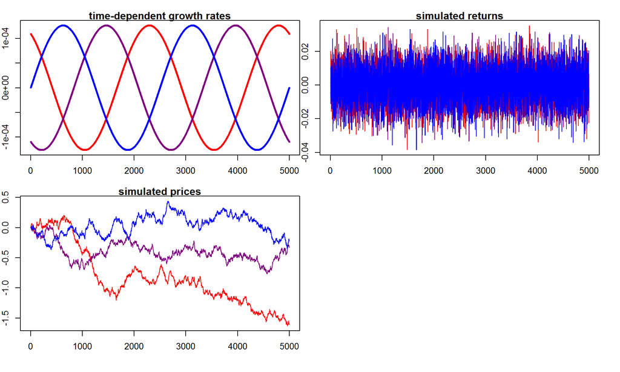

## Trend-following: Select Best Manager From Previous Period

[figure not shown]

## Ensemble: Select Top Two Managers From Previous Period

[figure not shown]

## Long-short Ensemble: Long Top Manager and Short Bottom Manager

[figure not shown]